# Organising proteomic and depression data UK Biobank

```r
library(dplyr)
library(data.table)
library(ggplot2)
library(parallel)
library(glue)
library(tidyr)
pops <- c("AFR", "EUR", "EAS", "SAS")
prsdir <- "/mnt/project/mdd-prs"
```

## Background

- get PCs
- get depression status
- identify individuals who did not have depression at baseline
- Read in PRS scores for each ancestry, and protein levels
- Regress protein ~ PRS for each protein and ancestry, including covariates
- Lookup agreement of assocs across ancestries
- Regression in controls only (i.e. excluding individuals who had first episode before enrollment date)

## Read in data

Protein level data is 50k samples by 1500 protein levels. Check missingness

```r
prot <- fread(file.path(prsdir, "data.csv"), sep=",", fill=TRUE)
```

```
|--------------------------------------------------|
|==================================================|
```

```r
prot <- as_tibble(prot)
dim(prot)
```

```
[1] 52704  1464
```

```r
sum(is.na(prot)) / sum(!is.na(prot))
```

```
[1] 0.02969722
```

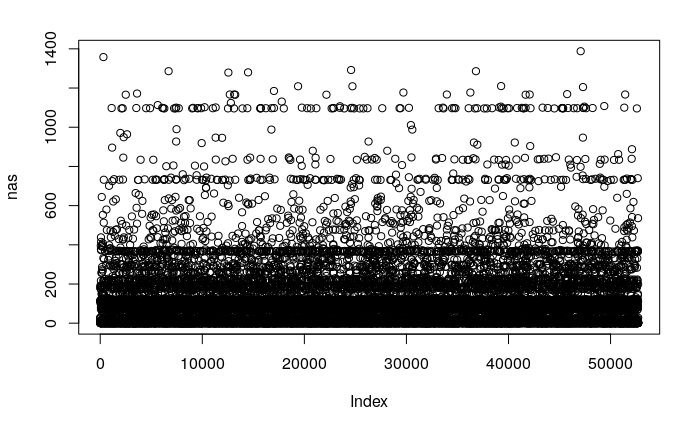

```r
nas <- apply(prot, 1, \(x) sum(is.na(x)))
plot(nas)
```

```r
length(nas)
```

```
[1] 52704
```

```r
sum(nas > 0.1*ncol(prot))
```

```
[1] 4051
```

TODO: remove proteins and individuals with high missingness e.g. > 10%

Format data…

```r
prot2 <- lapply(prot, as.numeric) %>% bind_cols()
prot2[1:10,1:10]
```

| eid | aarsd1 | abhd14b | abl1 | acaa1 | acan | ace2 | acox1 | acp5 | acp6 |
| --- | --- | --- | --- | --- | --- | --- | --- | --- | --- |
| 1000441 | 0.22320 | 0.10820 | 0.94790 | 0.8313 | 0.00000 | -0.02015 | 0.51290 | -0.33940 | 0.09200 |
| 1001143 | -0.00750 | 0.23710 | -0.08170 | 0.4223 | -0.75930 | -0.07370 | 0.83090 | -0.28040 | -1.92760 |
| 1001347 | 1.08955 | 0.51325 | 0.26505 | 0.8047 | NA | 0.07480 | NA | 0.05405 | -0.47225 |
| 1001982 | 0.08095 | 0.00685 | 0.29170 | -0.2310 | 0.21905 | -0.69550 | -0.06240 | -0.00230 | -1.10640 |
| 1002490 | 0.06040 | -0.18770 | -0.02440 | 0.0501 | 0.60920 | 0.70075 | -0.99050 | 0.67100 | -0.34710 |
| 1003210 | -0.14025 | 0.75485 | 1.01405 | 0.3752 | 0.39450 | -0.07300 | 0.40555 | -0.31005 | 0.95505 |
| 1003594 | 1.00085 | 0.43110 | 0.67980 | 0.7415 | -0.59550 | -0.02795 | -0.01000 | -0.36470 | -0.19310 |
| 1003799 | -0.15810 | -0.08200 | 0.09800 | 1.3189 | 0.11170 | -0.25455 | 0.87300 | 0.19810 | 1.17750 |
| 1004189 | -0.18315 | -0.43125 | -0.12825 | -0.5968 | -0.05090 | 0.15160 | 0.05395 | -0.45885 | 0.60025 |
| 1004313 | -0.08660 | -0.16280 | -0.01420 | 0.3259 | -0.75360 | 1.60005 | -0.40850 | -0.29230 | 0.58280 |

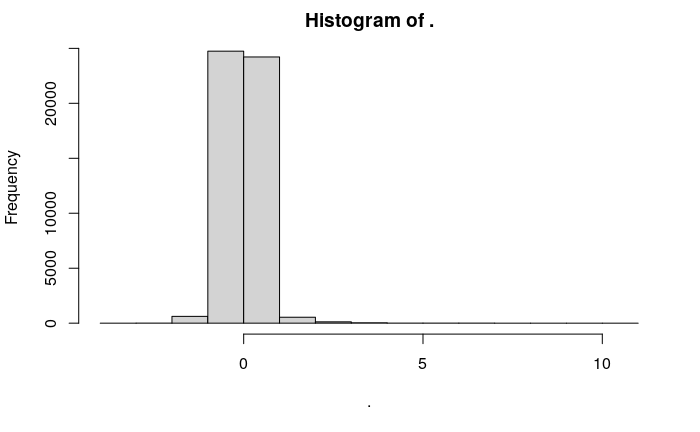

```r
ids <- prot2[,1]
prot2 <- prot2[,-1]
unlist(prot2[,100]) %>% hist
```

Lots of outliers. Set any to NA with values mean +/- 5*sd

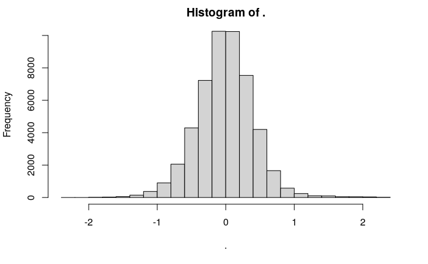

```r
remove_outliers <- function(v, sds=5) {
  m <- mean(v, na.rm=T)
  s <- sd(v, na.rm=T)
  v[v > (m + s*sds)] <- NA
  v[v < (m - s*sds)] <- NA
  return(v)
}
prot3 <- lapply(prot2, \(x) unlist(x) %>% remove_outliers) %>% bind_cols()
unlist(prot3[,100]) %>% hist
```

## Read in polygenic scores

Each population has a different polygenic score generated from PRScsx

```r
s <- lapply(pops, \(x) {
  fread(file.path(prsdir, "PRS", paste0("mdd_score_", x, ".profile"))) %>%
    as_tibble() %>%
    mutate(pop=x)
}) %>% bind_rows()
s
```

| FID | IID | PHENO | CNT | CNT2 | SCORE | pop |
| --- | --- | --- | --- | --- | --- | --- |
| 1002247 | 1002247 | -9 | 1797428 | 693125 | -9.43177e-07 | AFR |
| 1006417 | 1006417 | -9 | 1783854 | 686872 | -9.60186e-07 | AFR |
| 1010832 | 1010832 | -9 | 1807946 | 694234 | -8.49327e-07 | AFR |
| 1011573 | 1011573 | -9 | 1800158 | 691214 | -6.42474e-07 | AFR |
| 1016422 | 1016422 | -9 | 1739106 | 665642 | -6.52316e-07 | AFR |
| 1023554 | 1023554 | -9 | 1824118 | 701478 | -3.60322e-07 | AFR |
| 1030692 | 1030692 | -9 | 1775948 | 681396 | -9.80176e-07 | AFR |
| 1036632 | 1036632 | -9 | 1786106 | 686626 | -1.03320e-06 | AFR |
| 1037714 | 1037714 | -9 | 1812454 | 703623 | -1.00954e-06 | AFR |
| 1049054 | 1049054 | -9 | 1785398 | 688014 | -4.95797e-07 | AFR |

[output cut: 990 more lines]

Distributions of scores

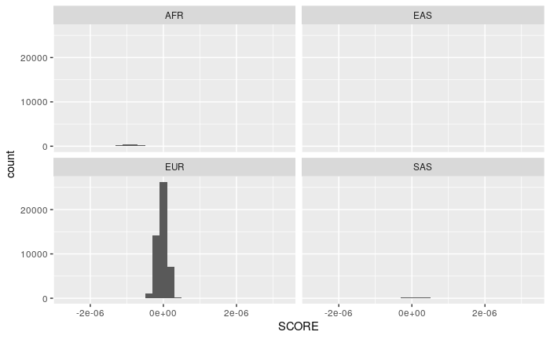

```r
ggplot(s, aes(SCORE)) +
  geom_histogram() +
  facet_wrap(~ pop)
```

Normalise scores by ancestry so that results are more easily comparable

```r
s <- s %>% group_by(pop) %>%
  mutate(normscore = scale(SCORE) %>% drop)
```

Organise protein levels further

```r
prot4 <- lapply(pops, \(x) {
  prot3$id <- as.integer(unlist(ids))
  inner_join(
    s %>% filter(pop == x) %>% select(id=FID, normscore),
    prot3
  )
})
names(prot4) <- pops
prot4[[1]][1:10,1:10]
```

| pop | id | normscore | aarsd1 | abhd14b | abl1 | acaa1 | acan | ace2 | acox1 |
| --- | --- | --- | --- | --- | --- | --- | --- | --- | --- |
| AFR | 1002247 | -0.03112542 | -0.81795 | 0.57365 | 0.8115 | -0.86425 | -0.30150 | -0.24265 | 0.4529 |
| AFR | 1006417 | -0.09193885 | 0.93050 | -0.48720 | -0.5050 | -0.17590 | 0.03820 | 0.48525 | -0.9234 |
| AFR | 1010832 | 0.30442285 | 0.42170 | 0.30860 | 0.8793 | 0.20110 | -0.04430 | 0.15535 | -0.1042 |
| AFR | 1011573 | 1.04399840 | 0.93220 | 0.00510 | -0.5028 | -0.10270 | -0.01490 | -0.57245 | -1.0796 |
| AFR | 1016422 | 1.00880963 | 0.54710 | 0.06200 | 0.1564 | -0.20120 | -0.24370 | -0.16860 | -0.5842 |
| AFR | 1023554 | 2.05279556 | 0.12660 | -0.21560 | -0.1590 | 0.36960 | -0.52060 | 0.44110 | -0.3668 |
| AFR | 1030692 | -0.16341045 | 0.58735 | 0.07930 | 0.2221 | 1.24390 | -0.33320 | 0.22985 | -0.0503 |
| AFR | 1036632 | -0.35299075 | -0.06425 | 0.02865 | 0.6250 | 0.39310 | 0.20515 | -0.11160 | 0.9151 |
| AFR | 1037714 | -0.26839755 | -0.95605 | -0.51725 | -0.3618 | -0.43630 | -0.02845 | 0.59370 | -0.8312 |
| AFR | 1049054 | 1.56842261 | 1.34685 | 0.33130 | -0.0743 | -0.03420 | 0.48270 | 0.47005 | 0.0887 |

## Get Principal components

Generated independently within each ancestry.

```r
pcs <- lapply(pops, \(x) {
  fread(file.path(prsdir, "PRS", paste0("mdd_score_", x, ".eigenvec"))) %>%
  mutate(pop=x)
}) %>% bind_rows()
pcs
```

| V1 | V2 | V3 | V4 | V5 | V6 | V7 | V8 | V9 | V10 | V11 | V12 | V13 | V14 | V15 | V16 | V17 | V18 | V19 | V20 | V21 | V22 | pop |
| --- | --- | --- | --- | --- | --- | --- | --- | --- | --- | --- | --- | --- | --- | --- | --- | --- | --- | --- | --- | --- | --- | --- |
| 1002247 | 1002247 | -1.03544e-03 | 3.26733e-03 | -1.89010e-02 | -4.19147e-02 | 2.87291e-03 | -2.10468e-02 | 6.05743e-04 | 2.12067e-02 | -3.35756e-02 | -5.20483e-02 | 2.31802e-02 | 2.71521e-03 | 1.36752e-02 | -7.34284e-05 | -1.70353e-03 | -4.27303e-03 | -1.66562e-03 | -7.68925e-03 | -1.90099e-03 | -4.47672e-04 | AFR |
| 1006417 | 1006417 | 1.90798e-02 | 2.15116e-03 | 2.22344e-02 | 1.14335e-02 | -4.43664e-03 | -5.23936e-03 | -8.51442e-03 | 8.75297e-03 | 1.15550e-02 | -5.73072e-03 | 1.60106e-02 | -4.97940e-03 | -3.09200e-03 | -4.41635e-03 | -7.74333e-04 | 3.94245e-03 | 3.25076e-03 | -6.77559e-03 | 1.76397e-02 | 1.60630e-02 | AFR |
| 1010832 | 1010832 | -5.82259e-03 | 1.21251e-02 | 1.97394e-02 | 3.48462e-04 | -5.70523e-03 | -6.08596e-03 | 3.18809e-03 | 2.71838e-02 | -4.93019e-02 | -2.14969e-02 | -4.89209e-02 | 5.45800e-03 | -1.90357e-02 | 2.63051e-02 | -3.37551e-02 | 1.27579e-02 | -1.60790e-02 | 1.43186e-02 | 5.78387e-02 | -9.62138e-03 | AFR |
| 1011573 | 1011573 | 2.06972e-02 | 4.71666e-03 | 8.64662e-03 | 4.41101e-03 | 1.80414e-04 | -9.19928e-03 | 2.93984e-03 | -3.75403e-03 | -3.32377e-03 | 3.74944e-03 | -1.51871e-03 | 5.77819e-03 | 9.58383e-03 | -3.22284e-03 | -1.01762e-03 | 2.04221e-03 | -1.07620e-03 | 5.45589e-03 | 6.12257e-04 | 4.52269e-03 | AFR |
| 1016422 | 1016422 | -4.79500e-02 | -1.28080e-01 | 2.37423e-02 | 1.22364e-02 | -3.48710e-02 | -6.67919e-02 | 5.43162e-02 | -2.93592e-02 | -3.80404e-02 | 2.04144e-02 | -7.56151e-03 | -3.48305e-02 | 4.79568e-02 | -4.40189e-02 | 5.03874e-03 | -1.13785e-02 | 1.56397e-02 | -2.65688e-02 | -5.82118e-03 | 3.20107e-02 | AFR |
| 1023554 | 1023554 | -5.46642e-02 | 1.90941e-02 | -4.98780e-02 | -5.03778e-02 | -3.24438e-02 | -3.82870e-02 | -1.71390e-02 | -2.14097e-02 | -2.91609e-03 | -1.43049e-01 | 1.70313e-01 | 5.30010e-02 | -3.68614e-02 | 2.01563e-02 | 1.65972e-02 | -9.02396e-03 | -2.71599e-02 | 1.15255e-01 | 4.47042e-02 | -1.88678e-02 | AFR |
| 1030692 | 1030692 | 1.61476e-02 | -5.13797e-03 | 1.36513e-02 | 2.56300e-02 | -4.37993e-04 | 1.20162e-02 | -1.01002e-02 | 1.03768e-02 | 1.40726e-02 | -4.45623e-03 | 1.11251e-02 | -1.58234e-03 | 2.08436e-02 | -1.23607e-02 | -2.29252e-02 | 7.43074e-03 | -8.99915e-05 | -2.65131e-03 | -3.98350e-02 | -9.67507e-03 | AFR |
| 1036632 | 1036632 | 1.84369e-02 | 1.69493e-03 | 1.84486e-03 | 9.07810e-03 | 7.81732e-05 | -3.74034e-04 | 1.73986e-03 | -2.16901e-03 | -3.25985e-03 | -3.64426e-04 | 9.87911e-04 | 8.63266e-03 | 7.58141e-03 | 8.10489e-03 | -3.97632e-03 | -1.11639e-02 | 1.23969e-02 | 6.88470e-03 | 5.26936e-03 | -1.53063e-02 | AFR |
| 1037714 | 1037714 | -4.55689e-02 | 2.93158e-02 | -7.10007e-02 | 7.43241e-02 | 1.00805e-02 | 1.70925e-02 | 6.02609e-02 | -1.10889e-02 | -3.07094e-02 | 1.10192e-01 | 7.50552e-02 | -6.78465e-02 | -1.13002e-01 | -3.49503e-02 | 2.28919e-04 | -1.61119e-02 | 2.18985e-02 | -2.61713e-02 | -5.09988e-02 | 3.03363e-02 | AFR |
| 1049054 | 1049054 | 1.84662e-02 | -5.31240e-03 | -1.99019e-02 | -1.78565e-02 | -1.42875e-02 | -1.54743e-03 | 2.36784e-03 | -3.01318e-03 | 2.23230e-03 | 1.12947e-02 | 2.92700e-03 | -1.67451e-04 | -5.97536e-03 | -7.02268e-03 | 1.63281e-02 | 1.40671e-03 | -1.49741e-03 | 9.78672e-04 | 1.47207e-02 | 1.01030e-03 | AFR |

[output cut: 990 more lines]

Plot PCs for each ancestry

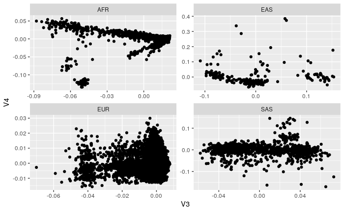

```r
pcs %>%
  ggplot(aes(V3, V4)) +
  geom_point() +
  facet_wrap(~ pop, scale="free")
```

Plot ancestry by global PCs. Read in PCs generated on all individuals and then annotate individuals by their assigned ancestry

```r
ukbpcs <- fread("/mnt/project/Bulk/Genotype Results/Genotype calls/ukb_sqc_v2.txt")
```

```
|--------------------------------------------------|
|==================================================|
```

```r
str(ukbpcs)
```

```
Classes ‘data.table’ and 'data.frame':  488377 obs. of  68 variables:
 $ V1 : chr  "A550484-4214737-041115-493_A01" "A550484-4214737-041115-493_A02" "A550484-4214737-041115-493_A03" "A550484-4214737-041115-493_A04" ...
 $ V2 : int  2032476 2868665 5580157 5184402 1114375 1334561 5551233 2911257 3261612 5352063 ...
 $ V3 : chr  "UKBB" "UKBB" "UKBB" "UKBB" ...
 $ V4 : chr  "Batch_b001" "Batch_b001" "Batch_b001" "Batch_b001" ...
 $ V5 : chr  "SMP4_0012258" "SMP4_0012258" "SMP4_0012258" "SMP4_0012258" ...
 $ V6 : chr  "A01" "A02" "A03" "A04" ...
 $ V7 : num  99.2 99.6 99.7 99.7 99.6 ...
 $ V8 : num  0.96 0.97 0.98 0.98 0.98 0.96 0.95 0.96 0.96 0.94 ...
 $ V9 : num  33.1 30.3 39 39.1 48.3 ...
 $ V10: chr  "M" "F" "F" "F" ...
 $ V11: chr  "M" "F" "F" "F" ...
 $ V12: num  508 644 722 770 748 ...
 $ V13: num  578 281 312 330 335 ...
 $ V14: chr  "SMP4_0012258" "SMP4_0012258" "SMP4_0012258" "SMP4_0012258" ...
```

[output cut: 55 more lines]

```r
fam <- fread("/mnt/project/Bulk/Genotype Results/Genotype calls/ukb22418_cY_b0_v2.fam")
dim(fam)
```

```
[1] 488377      6
```

```r
ukbpcs$eid <- fam$V1
table(pcs$V1 %in% ukbpcs$eid)
```

```
 TRUE
51457
```

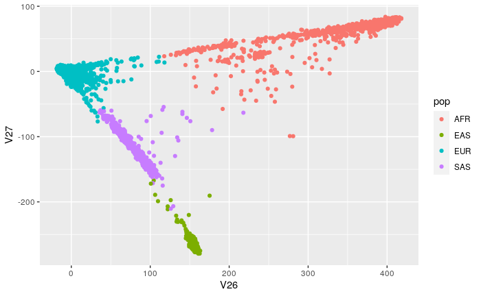

```r
temp <- inner_join(
  ukbpcs %>% select(eid, V26, V27),
  pcs %>% select(eid=V1, pop, V3, V4),
)
ggplot(temp, aes(V26, V27)) +
  geom_point(aes(colour=pop))
```

Looks like individuals are assigned to ancestry reasonably well

## Get other variables

Depression phenotypes, including case control status, age of first episode, age of enrollment into UK Biobank. Blood samples were taken at enrollment, therefore anyone whose first episode was after enrollment form a prospective cohort.

```r
phen <- fread(file.path(prsdir, "mdd-prs-baseline_participant.csv"))
names(phen) <- c("eid", "age_first_episode", "age_enrollment", "yearbirth", "sex", "deprivation")
table(prot$eid %in% phen$eid)
```

```
 TRUE
52704
```

```r
table(pcs$V1 %in% phen$eid)
```

```
 TRUE
51457
```

```r
dim(pcs)
```

```
[1] 51457    23
```

```r
table(s$IID %in% pcs$V1)
```

```
 TRUE
51457
```

Ancestry proportions in the sample

```r
phen <- inner_join(phen, pcs %>% select(eid=V1, pop))
table(phen$pop)
```

```
  AFR   EAS   EUR   SAS
 1467   245 48740  1005
```

Depression prevalence

```r
phen$depression <- as.numeric(phen$age_first_episode != "")
table(phen$depression)
```

```
    0     1
42359  9098
```

Depression prevalence by ancestry

```r
table(phen$depression, phen$pop)
```

```
      AFR   EAS   EUR   SAS
  0  1377   226 39823   933
  1    90    19  8917    72
```

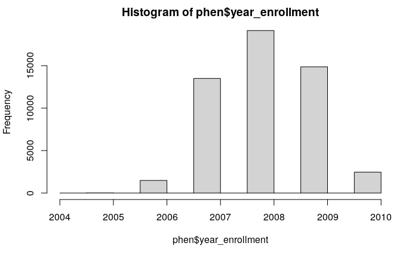

```r
phen$year_enrollment <- phen$yearbirth + phen$age_enrollment
hist(phen$year_enrollment)
```

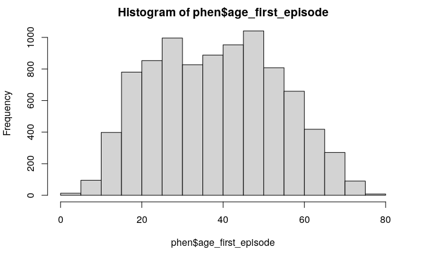

```r
phen$age_first_episode[phen$age_first_episode=="Do not know"] <- phen$age_enrollment[phen$age_first_episode=="Do not know"]
phen$age_first_episode[phen$age_first_episode=="Prefer not to answer"] <- phen$age_enrollment[phen$age_first_episode=="Prefer not to answer"]
phen$age_first_episode <- as.numeric(phen$age_first_episode)
hist(phen$age_first_episode)
```

```r
dat <- inner_join(
  pcs %>% select(eid=V1, V1:V22),
  phen
)
dat <- inner_join(dat, s %>% select(eid=IID, normscore))
str(dat)
```

```
Classes ‘data.table’ and 'data.frame':  51457 obs. of  31 variables:
 $ eid              : int  1002247 1006417 1010832 1011573 1016422 1023554 1030692 1036632 1037714 1049054 ...
 $ V2               : int  1002247 1006417 1010832 1011573 1016422 1023554 1030692 1036632 1037714 1049054 ...
 $ V3               : num  -0.00104 0.01908 -0.00582 0.0207 -0.04795 ...
 $ V4               : num  0.00327 0.00215 0.01213 0.00472 -0.12808 ...
 $ V5               : num  -0.0189 0.02223 0.01974 0.00865 0.02374 ...
 $ V6               : num  -0.041915 0.011433 0.000348 0.004411 0.012236 ...
 $ V7               : num  0.00287 -0.00444 -0.00571 0.00018 -0.03487 ...
 $ V8               : num  -0.02105 -0.00524 -0.00609 -0.0092 -0.06679 ...
 $ V9               : num  0.000606 -0.008514 0.003188 0.00294 0.054316 ...
 $ V10              : num  0.02121 0.00875 0.02718 -0.00375 -0.02936 ...
 $ V11              : num  -0.03358 0.01155 -0.0493 -0.00332 -0.03804 ...
 $ V12              : num  -0.05205 -0.00573 -0.0215 0.00375 0.02041 ...
 $ V13              : num  0.02318 0.01601 -0.04892 -0.00152 -0.00756 ...
 $ V14              : num  0.00272 -0.00498 0.00546 0.00578 -0.03483 ...
```

[output cut: 18 more lines]

```r
save(dat, prot4, file="ukb_prot_mdd.rdata")
```

## Perform associations

```r
fast_assoc <- function(y, x) {
    index <- is.finite(y) & is.finite(x)
    n <- sum(index)
    y <- y[index]
    x <- x[index]
    #vx <- var(x)
    vy <- var(y)
    bhat <- stats::cov(y, x) / vy
    ahat <- mean(x) - bhat * mean(y)
    # fitted <- ahat + x * bhat
    # residuals <- y - fitted
    # SSR <- sum((residuals - mean(residuals))^2)
    # SSF <- sum((fitted - mean(fitted))^2)

    rsq <- (bhat * vy)^2 / (vy * var(x))
    fval <- rsq * (n-2) / (1-rsq)
    tval <- sqrt(fval)
    se <- abs(bhat / tval)

    # Fval <- (SSF) / (SSR/(n-2))
    # pval <- pf(Fval, 1, n-2, lowe=F)
    p <- stats::pf(fval, 1, n-2, lower.tail=FALSE)
    return(list(
        ahat=ahat, bhat=bhat, se=se, fval=fval, pval=p, n=n
    ))
}

phewas <- function(y, g, logistic=FALSE) {
    out <- matrix(0, ncol(g), 6)
    if(logistic)
    {
        stopifnot(all(y %in% c(0,1)))
        for(i in 1:ncol(g))
        {
            o <- logistic_assoc(y, g[,i])
            out[i, ] <- unlist(o)
        }
    } else {
        for(i in 1:ncol(g))
        {
            o <- fast_assoc(y, g[,i])
            out[i, ] <- unlist(o)
        }
    }

    out <- dplyr::as_tibble(out, .name_repair="minimal")
    names(out) <- names(o)
    out$snp <- 1:ncol(g)
    return(out)
}
```

Perform simple analysis - no covariates etc

```r
rsimple <- lapply(pops, \(p) {
  x <- prot4[[p]]
  o <- phewas(y=unlist(x$normscore), g=as.matrix(as.matrix(x[,4:ncol(x)])))
  o$pop=p
  o$prot <- colnames(x[4:ncol(x)])
  o$fdr <- p.adjust(o$pval, "fdr")
  return(o)
}) %>% bind_rows()

rsimple %>% group_by(pop) %>%
  summarise(n=sum(fdr < 0.05))
```

| pop | n |
| --- | --- |
| AFR | 157 |
| EAS | 0 |
| EUR | 824 |
| SAS | 1 |

Try comparing across ancestries

```r
rw <- spread(rsimple %>% select(pop, bhat, prot), key=pop, value=bhat)
head(rw)
```

| prot | AFR | EAS | EUR | SAS |
| --- | --- | --- | --- | --- |
| aarsd1 | -0.021884648 | -0.083471512 | -0.0006533191 | -0.008201161 |
| abhd14b | -0.003198397 | -0.009580136 | 0.0018993516 | -0.015367693 |
| abl1 | 0.014050838 | -0.017634115 | 0.0158039676 | -0.007432593 |
| acaa1 | 0.002108127 | 0.006835172 | 0.0281754430 | 0.022946452 |
| acan | 0.002769477 | -0.022201960 | -0.0069292454 | 0.014915779 |
| ace2 | 0.015661088 | 0.023221012 | 0.0221195557 | 0.050362540 |

```r
eur_index <- subset(rsimple, pop=="EUR" & fdr < 0.05)$prot
afr_index <- subset(rsimple, pop=="AFR" & fdr < 0.05)$prot
summary(lm(AFR ~ EUR, rw, subset=rw$prot %in% eur_index))
```

```
Call:
lm(formula = AFR ~ EUR, data = rw, subset = rw$prot %in% eur_index)

Residuals:
      Min        1Q    Median        3Q       Max
-0.184548 -0.013906 -0.001265  0.014699  0.178462

Coefficients:
             Estimate Std. Error t value Pr(>|t|)
(Intercept) 0.0002764  0.0012220   0.226    0.821
EUR         0.5615623  0.0837319   6.707  3.7e-11 ***
---
Signif. codes:  0 ‘***’ 0.001 ‘**’ 0.01 ‘*’ 0.05 ‘.’ 0.1 ‘ ’ 1

Residual standard error: 0.02728 on 822 degrees of freedom
Multiple R-squared:  0.05188,   Adjusted R-squared:  0.05073
F-statistic: 44.98 on 1 and 822 DF,  p-value: 3.702e-11
```

```r
summary(lm(AFR ~ EUR, rw))
```

```
Call:
lm(formula = AFR ~ EUR, data = rw)

Residuals:
      Min        1Q    Median        3Q       Max
-0.183607 -0.013026 -0.000318  0.014712  0.179618

Coefficients:
              Estimate Std. Error t value Pr(>|t|)
(Intercept) -0.0007155  0.0008407  -0.851    0.395
EUR          0.5644430  0.0744677   7.580 6.12e-14 ***
---
Signif. codes:  0 ‘***’ 0.001 ‘**’ 0.01 ‘*’ 0.05 ‘.’ 0.1 ‘ ’ 1

Residual standard error: 0.02745 on 1461 degrees of freedom
Multiple R-squared:  0.03784,   Adjusted R-squared:  0.03718
F-statistic: 57.45 on 1 and 1461 DF,  p-value: 6.122e-14
```

```r
summary(lm(EAS ~ EUR, rw, subset=rw$prot %in% eur_index))
```

```
Call:
lm(formula = EAS ~ EUR, data = rw, subset = rw$prot %in% eur_index)

Residuals:
      Min        1Q    Median        3Q       Max
-0.186033 -0.017690  0.000984  0.017625  0.243633

Coefficients:
             Estimate Std. Error t value Pr(>|t|)
(Intercept) -0.001318   0.001555  -0.847    0.397
EUR          1.076857   0.106570  10.105   <2e-16 ***
---
Signif. codes:  0 ‘***’ 0.001 ‘**’ 0.01 ‘*’ 0.05 ‘.’ 0.1 ‘ ’ 1

Residual standard error: 0.03472 on 822 degrees of freedom
Multiple R-squared:  0.1105,    Adjusted R-squared:  0.1094
F-statistic: 102.1 on 1 and 822 DF,  p-value: < 2.2e-16
```

```r
summary(lm(SAS ~ EUR, rw, subset=rw$prot %in% eur_index))
```

```
Call:
lm(formula = SAS ~ EUR, data = rw, subset = rw$prot %in% eur_index)

Residuals:
      Min        1Q    Median        3Q       Max
-0.088718 -0.014072  0.002124  0.014110  0.105046

Coefficients:
            Estimate Std. Error t value Pr(>|t|)
(Intercept) 0.001343   0.001091   1.231    0.219
EUR         0.573008   0.074772   7.663  5.1e-14 ***
---
Signif. codes:  0 ‘***’ 0.001 ‘**’ 0.01 ‘*’ 0.05 ‘.’ 0.1 ‘ ’ 1

Residual standard error: 0.02436 on 822 degrees of freedom
Multiple R-squared:  0.06668,   Adjusted R-squared:  0.06555
F-statistic: 58.73 on 1 and 822 DF,  p-value: 5.101e-14
```

```r
summary(lm(AFR ~ EUR, rw, subset=rw$prot %in% eur_index))
```

```
Call:
lm(formula = AFR ~ EUR, data = rw, subset = rw$prot %in% eur_index)

Residuals:
      Min        1Q    Median        3Q       Max
-0.184548 -0.013906 -0.001265  0.014699  0.178462

Coefficients:
             Estimate Std. Error t value Pr(>|t|)
(Intercept) 0.0002764  0.0012220   0.226    0.821
EUR         0.5615623  0.0837319   6.707  3.7e-11 ***
---
Signif. codes:  0 ‘***’ 0.001 ‘**’ 0.01 ‘*’ 0.05 ‘.’ 0.1 ‘ ’ 1

Residual standard error: 0.02728 on 822 degrees of freedom
Multiple R-squared:  0.05188,   Adjusted R-squared:  0.05073
F-statistic: 44.98 on 1 and 822 DF,  p-value: 3.702e-11
```

```r
summary(lm(EUR ~ AFR, rw, subset=rw$prot %in% afr_index))
```

```
Call:
lm(formula = EUR ~ AFR, data = rw, subset = rw$prot %in% afr_index)

Residuals:
      Min        1Q    Median        3Q       Max
-0.030027 -0.006280  0.000137  0.004697  0.027696

Coefficients:
            Estimate Std. Error t value Pr(>|t|)
(Intercept) 0.004252   0.000834   5.099 9.86e-07 ***
AFR         0.060802   0.014414   4.218 4.17e-05 ***
---
Signif. codes:  0 ‘***’ 0.001 ‘**’ 0.01 ‘*’ 0.05 ‘.’ 0.1 ‘ ’ 1

Residual standard error: 0.01031 on 155 degrees of freedom
Multiple R-squared:  0.103, Adjusted R-squared:  0.09719
F-statistic: 17.79 on 1 and 155 DF,  p-value: 4.174e-05
```

```r
summary(lm(EUR ~ AFR, rw))
```

```
Call:
lm(formula = EUR ~ AFR, data = rw)

Residuals:
      Min        1Q    Median        3Q       Max
-0.072644 -0.005604 -0.000562  0.004843  0.065973

Coefficients:
             Estimate Std. Error t value Pr(>|t|)
(Intercept) 0.0057064  0.0002484   22.98  < 2e-16 ***
AFR         0.0670321  0.0088436    7.58 6.12e-14 ***
---
Signif. codes:  0 ‘***’ 0.001 ‘**’ 0.01 ‘*’ 0.05 ‘.’ 0.1 ‘ ’ 1

Residual standard error: 0.009459 on 1461 degrees of freedom
Multiple R-squared:  0.03784,   Adjusted R-squared:  0.03718
F-statistic: 57.45 on 1 and 1461 DF,  p-value: 6.122e-14
```

```r
summary(lm(SAS ~ AFR, rw, subset=rw$prot %in% afr_index))
```

```
Call:
lm(formula = SAS ~ AFR, data = rw, subset = rw$prot %in% afr_index)

Residuals:
      Min        1Q    Median        3Q       Max
-0.050073 -0.011972 -0.000375  0.010426  0.053946

Coefficients:
            Estimate Std. Error t value Pr(>|t|)
(Intercept) 0.011224   0.001531   7.332 1.18e-11 ***
AFR         0.109056   0.026458   4.122 6.11e-05 ***
---
Signif. codes:  0 ‘***’ 0.001 ‘**’ 0.01 ‘*’ 0.05 ‘.’ 0.1 ‘ ’ 1

Residual standard error: 0.01892 on 155 degrees of freedom
Multiple R-squared:  0.09878,   Adjusted R-squared:  0.09297
F-statistic: 16.99 on 1 and 155 DF,  p-value: 6.105e-05
```

```r
summary(lm(EAS ~ AFR, rw, subset=rw$prot %in% afr_index))
```

```
Call:
lm(formula = EAS ~ AFR, data = rw, subset = rw$prot %in% afr_index)

Residuals:
      Min        1Q    Median        3Q       Max
-0.097760 -0.015047 -0.000129  0.015207  0.108119

Coefficients:
            Estimate Std. Error t value Pr(>|t|)
(Intercept) 0.002886   0.002583   1.117 0.265616
AFR         0.157132   0.044649   3.519 0.000568 ***
---
Signif. codes:  0 ‘***’ 0.001 ‘**’ 0.01 ‘*’ 0.05 ‘.’ 0.1 ‘ ’ 1

Residual standard error: 0.03193 on 155 degrees of freedom
Multiple R-squared:  0.07399,   Adjusted R-squared:  0.06802
F-statistic: 12.39 on 1 and 155 DF,  p-value: 0.0005683
```

```r
summary(lm(EAS ~ AFR, rw))
```

```
Call:
lm(formula = EAS ~ AFR, data = rw)

Residuals:
      Min        1Q    Median        3Q       Max
-0.265715 -0.019148 -0.000821  0.018973  0.241327

Coefficients:
            Estimate Std. Error t value Pr(>|t|)
(Intercept) 0.003652   0.001009   3.619 0.000306 ***
AFR         0.169539   0.035932   4.718 2.61e-06 ***
---
Signif. codes:  0 ‘***’ 0.001 ‘**’ 0.01 ‘*’ 0.05 ‘.’ 0.1 ‘ ’ 1

Residual standard error: 0.03843 on 1461 degrees of freedom
Multiple R-squared:  0.01501,   Adjusted R-squared:  0.01433
F-statistic: 22.26 on 1 and 1461 DF,  p-value: 2.606e-06
```

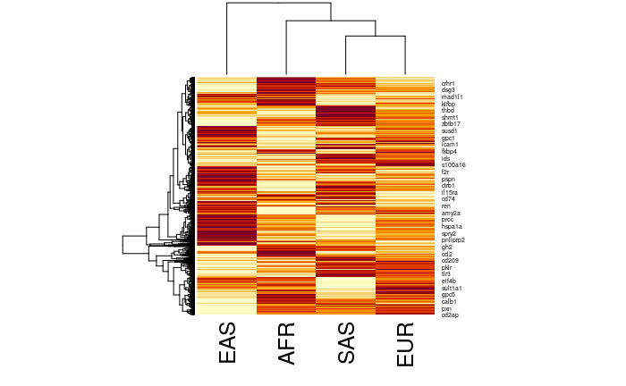

```r
rwm <- as.matrix(rw[,-1])
rownames(rwm) <- unlist(rw[,1])
heatmap(rwm)
```

Perform associations, adjusting for PCs, age etc

```r
phewas_covs <- function(prot4, dat) {
  lapply(names(prot4), \(anc) {
    x <- prot4[[anc]]
    x <- subset(x, id %in% dat$eid)
    ind <- match(x$id, dat$eid)
    d <- dat[ind, ]
    stopifnot(all(d$eid == x$id))
    mclapply(4:ncol(x), \(i) {
      o <- summary(lm(x[[i]] ~ d$normscore + d$age_enrollment + d$sex + d$V3 + d$V4 + d$V5 + d$V6 + d$V7 + d$V8 + d$V9 + d$V10 + d$V11 + d$V12))
      tibble(pop=anc, prot=names(x)[i], bhat=o$coef[2,1], se=o$coef[2,2], pval=o$coef[2,4], n=o$df[1] + o$df[2])
    }, mc.cores=parallel::detectCores()) %>% bind_rows()
  }) %>% bind_rows()
}

rcovs <- phewas_covs(prot4, dat)
rcovs$fdr <- p.adjust(rcovs$pval, "fdr")
table(rcovs$fdr < 0.05, rcovs$pop)
```

[output not shown]

[output not shown]

[output cut: 990 more lines]

Correlation of mddprs-prot assocs across ancestries

```r
cor(rwc[,-1], use="pair")
```

```
           AFR        EAS       EUR        SAS
AFR 1.00000000 0.02514474 0.2063473 0.39686127
EAS 0.02514474 1.00000000 0.2660496 0.02797388
EUR 0.20634732 0.26604961 1.0000000 0.28987229
SAS 0.39686127 0.02797388 0.2898723 1.00000000
```

regression of mddprs-prot assocs across ancestries, using all proteins, or just those that were FDR < 0.05 in the discovery ancestry

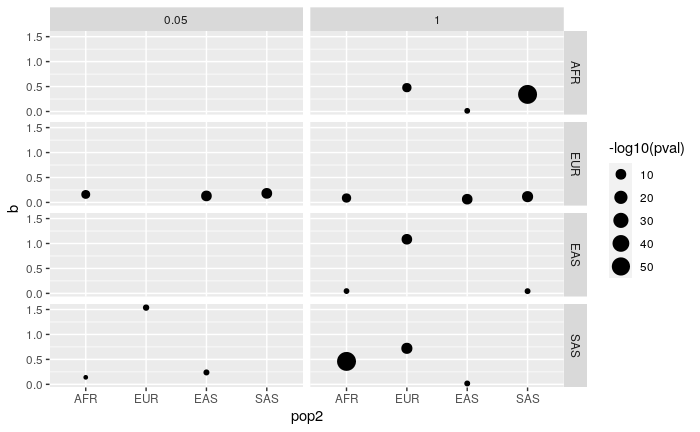

```r
comps %>%
  filter(pop1 != pop2) %>%
  ggplot(., aes(y=b, x=pop2)) +
  geom_point(aes(size=-log10(pval))) +
  facet_grid(pop1 ~ as.factor(fdr))
```

## Excluding cases

```r
table(dat$prospective, dat$pop)
```

```
         AFR  EAS  EUR  SAS
  FALSE   72   16 7763   57
  TRUE    18    3 1154   15
```